# STAT 331 Project Group I

Author

Derrick Phan, Steven Ortiz, Jaden Sung, Will Mathewson

## Data Cleaning

Before the analysis, we converted any GDP per Capita values into full numeric values. For example, income values like “31.7k” were converted to “31700” to allow for numerical analysis. We applied this conversion to all years for each country, then reshaped the table so that each row corresponds to a single country-year observation. We performed a similar conversion for the internet usage percentages before merging the two sources together.

## Modeling the Relationship between Average Internet Usage and GDP per Capita

**Data Visualization**

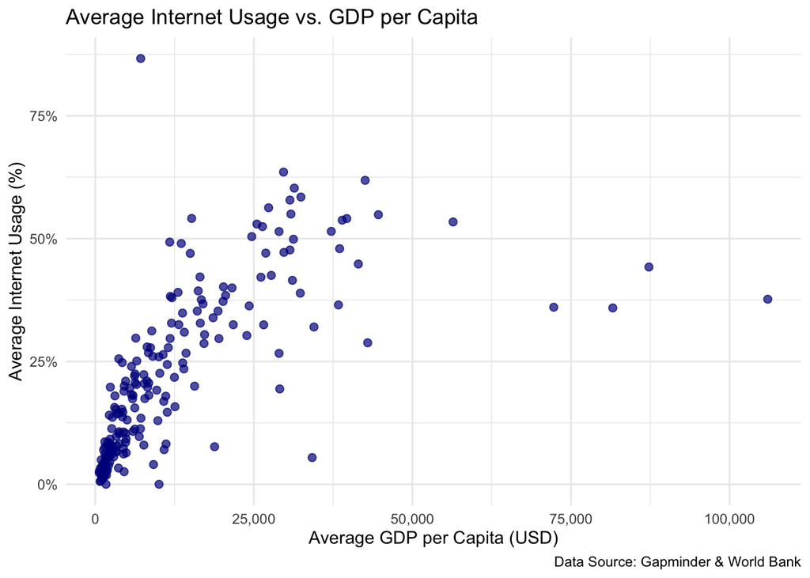

The above plot shows each country’s average GDP per Capita on the x‐axis and its average Internet usage rate on the y‐axis (across all available years). From this plot we can see a positive trend that countries with higher average income also tend to have greater internet usage.

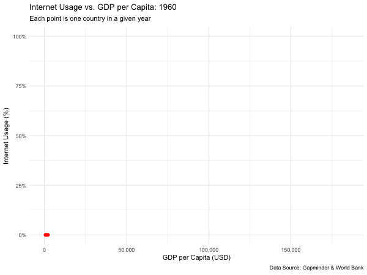

The animated plot here shows the change over time for all countries in within the dataset. Using the graph we can infer that over time, the internet usage increases alongside the GDP per Capita.

**Linear Regression**

For the linear regression, we chose to summarize our data by getting each country’s average GDP per capita and internet usage rate across all available years. This allows us to represent every country with a single point on the graph, thus enabling a linear regression line.

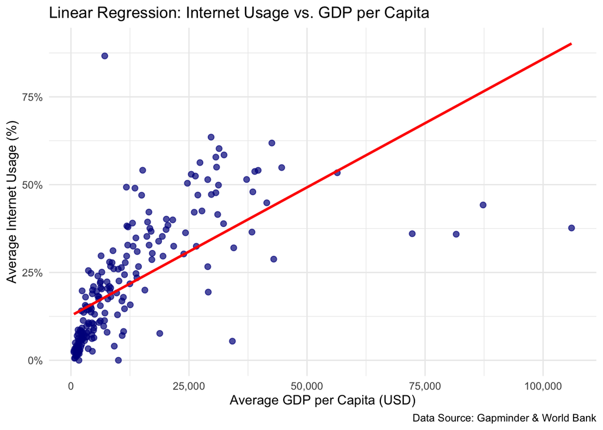

Linear Regression Coefficients: Internet Usage ~ GDP per Capita

| Term | Estimate | Std. Error | t‐value | p‐value |
| --- | --- | --- | --- | --- |
| Intercept | 12.683 | 1.196 | 10.603 | 3.96e-21 |
| Avg Income (USD) - Slope | 0.001 | 0.000 | 12.380 | 1.67e-26 |

From our linear regression model, we can see that
$$\widehat{\text{Internet}} \;=\; 12.683 \;+\; 0.001 \times \text{Income}.$$
The intercept (12.683) represents a baseline internet usage rate when income = 0, and the slope (0.001) indicates that a $1 increase in GDP per Capita corresponds to a 0.001 percentage‐point increase in internet usage.

**Model Fit**

Variances & R² for the Model

| Statistic | Value |
| --- | --- |
| Var(Response) = Var(avg_internet_users) | 298.517 |
| Var(Fitted) = Var(ŷ) | 129.507 |
| Var(Residuals) = Var(y − ŷ) | 169.010 |
| R² = B / A | 0.434 |

The table presents the variances as well the model R². It shows us that the total variability in average internet usage across countries is 298.517, of which 129.507 (about 43.4%) is explained by the linear relationship with average GDP per Capita; the remaining 169.010 represents unexplained variance.

Since R² = 0.434, our model accounts for roughly 43.4% of the variability in average internet usage. This suggests a moderate fit in our model where GDP per Capita explains some of the cross‐country differences in internet adoption.

## Cross Validation

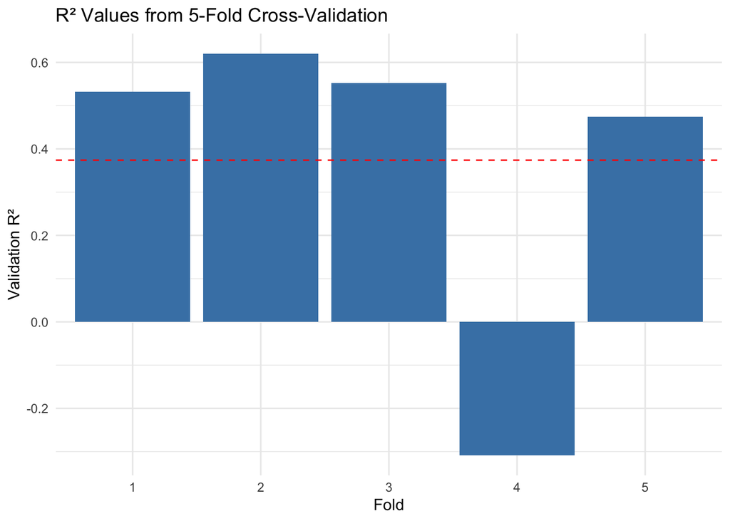

In our 5-fold cross-validation for our model, we randomly split the country data into five roughly equal groups (each with at least 10 countries). For each group, we trained the regression model on the other four folds, predicted the internet usage for fold, and computed the validation R².

## Conclusion

Our analysis reveals a positive relationship between a country’s per person wealth and its internet usage rates, which supports our initial hypothesis that greater individual wealth enables more access to technology. Although the model explains a notable portion of the variation in internet usage (as confirmed by the cross validation) there is still a large amount of the variation that was not explained by our model that could be accounted for by other factors. If we were to continue on with this project, we would explore other factors that caused variation and attempt to explain it and its relationship to internet usage. Overall, our final report suggests that per person wealth is only one of many factors influencing internet access.

*To continuing viewing our project, you can find the GitHub repo we used for our project here: [STAT 331 Project Group I GitHub Repository](https://github.com/derrickph33/stat331-proj-groupi)*

## References

n.d.a. *Gapminder*. https://www.gapminder.org/data/documentation/gd001/.

———. n.d.b. *World Bank Open Data*. https://data.worldbank.org/indicator/IT.NET.USER.ZS.

Author, No. 2014. “Greater Technology Use Linked to Higher Per Capita Income.” *Pew Research Center*. Pew Research Center. https://www.pewresearch.org/global/2014/02/13/developing-technology-use/.